# Econ241a assignment 8

Casey O’Hara

# 1 Try the following problem:

Draw $m$ iid standard normals, $x_i$, $i = 1, ..., m$. Compute the statistic

$$T = \frac{1}{m} \sum_{i=1}^M I(x_i < \Phi^{-1}(.025) \cup x_i > \Phi^{-1}(.975))$$

Now repeat this experiment $n$ times and show the distribution of $T$. Do this for $m = 100$ and $n = 1000$. Show what you get empirically as well as what the theoretical answer should be. (Remember that the test statistic is essentially an average of Bernoulli trials.)

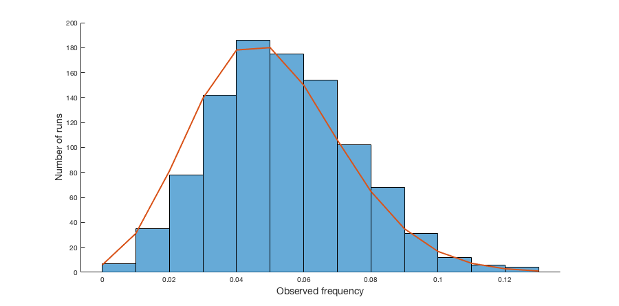

Code for `function [test_stat] = get_test_stat(m, n, pvals)`:

```r
function [test_stat] = get_test_stat(m, n, pvals)
%% Generate frequencies
%  Inputs: m = number of trials per sample
%          n = number of samples
%          pvals = lower bound and upper bound between 0 and 1

    % Generate z values from p values
    z_bounds = icdf('Normal', pvals, 0, 1);

    % Generate m x n matrix of randoms from standard normal
    sample_m_n = randn(m, n);

    % Compare samples to z bounds; outside bounds = 1 (T), inside = 0 (F)
    test_m_n = (sample_m_n < z_bounds(1) | sample_m_n > z_bounds(2) );

    test_count = sum(test_m_n)

    test_stat = test_count ./ m;

end
```

Code for `function [x, pdf] = get_bino_pdf(test_stat, m, pvals)`:

```r
function [x, pdf] = get_bino_pdf(test_stat, m, pvals)
%% Generate pdf
%  Since this is a set of Bernoulli trials, we can model it with a binomial
%  distribution...
%  Inputs:
%    pvals = p value lower and upper bounds (this is used to
%      determine the overall p for the binomial distribution)
%    m = number of trials in each sample

    p = 1 - (pvals(2) - pvals(1))

    x = 0:max(test_stat) .* m; % note this is in counts, not count/m

    pdf = binopdf(x, m, p);

end
```

Code for function calls and plotting:

```r
%% Set parameters

m = 100; n = 1000;
pvals = [.025, .975];

%%%%%%%%%%%%%%%%%%%%%%%%%%%%%%%%%%%%%%%%%%%%%%%%%%%%%%%%%%
%% Get test stats and binomial pdf based on these params
%%%%%%%%%%%%%%%%%%%%%%%%%%%%%%%%%%%%%%%%%%%%%%%%%%%%%%%%%%

test_stat = get_test_stat(m, n, pvals);

[x, pdf] = get_bino_pdf(test_stat, m, pvals);

%%%%%%%%%%%%%%%%%%%%%%%%%%%%%%%%%%%%%%%%%%%%%%%%%%%%%%%%%%
%% Plot histogram and pdf
%%%%%%%%%%%%%%%%%%%%%%%%%%%%%%%%%%%%%%%%%%%%%%%%%%%%%%%%%%

figure
hold on
    histogram(test_stat, 'BinWidth', 1/m);
    plot(x/m, pdf*n, 'linewidth', 2);
    xlabel('Observed frequency');
    ylabel('Number of runs');
hold off
```

# 2 Surveys in Nigeria:

My daughter is going to run a survey in Nigeria.

- Enumerators are expensive, so each marginal response costs $c = 2500$ naira.
  - 2500 naira $\approx$ $7.02.
- A field experiment is planned. A baseline survey was run before any treatment, which indicated that the standard deviation of the variable of interest is $\sigma = 4$ and that the responses are approximately normally distributed.
- My daughter believes the true effect size is $\mu = 2$.
- Finding a positive estimated effect size will result in a publication which will have a NPV for her career equal to $50,000.
- (A reminder that sample means are roughly normally distributed.)

How many surveys should my risk-neutral daughter buy?

## 2.1 Outline the process

Net present value of publication, contingent on positive results, is $E(pub|pos.result) = \$50,000$ (and assuming $E(pub|neg.result) = 0$…); however, those positive results come at the cost of $c = \$7.02$ per survey.

$$E(pub) = E(pub|pos.result) \times P(pos.result) - c_{survey} \times n$$

So we’d like to get $P(pos.result)$ in terms of $n$; differentiate this with respect to $n$, set to zero, and solve for $n$. Then check the second derivative to make sure we’ve found a maximum rather than a minimum, because that would be sad.

## 2.2 Find $g(n) = P(pos.result)$

From previous slides, probability of rejecting the null (in the example for $|z| > 1.96$) is $F_z(-z) + (1 - F_z(z))$.

We also know that $F_z = \Phi(z - \mu/\sqrt{\sigma^2/n})$. So:

$$\begin{align*}
P(pos.result) &= \Phi(-z - 2/\sqrt{4^2/n}) + (1 - \Phi(z - 2/\sqrt{4^2/n}))\\
&= \Phi(-z - \sqrt{n}/2) + (1 - \Phi(z - \sqrt{n}/2))
\end{align*}$$

## 2.3 Putting it all together

Assuming a successful result based on a p-value of 0.05, then $z = \pm1.96$.

$$\begin{align*}
\frac{d}{dn}[\$50000(\Phi(-1.96 - \sqrt{n}/2) +
(1 - \Phi(1.96 - \sqrt{n}/2))) - 7.02n] = 0\\
\$50000\times[\phi(-1.96 - \sqrt{n}/2) +
(1 - \phi(1.96 - \sqrt{n}/2))](\frac{1}{4\sqrt{n}}) - 7.02 = 0
\end{align*}$$

Solving for $n$ will be ugly, so let’s just calculate for $n$ from 1:200 and see where the slopes are equal.

```r
z <- 1.96
naira_to_dollars <- 7.02 ### 2500 naira = $7.02

value_by_n <- data.frame(n = 1:200) %>%
  mutate(cn = n * naira_to_dollars,
         phi_lo = pnorm(-1.96 - (2 / (sqrt(16 / n)))),
         phi_hi = pnorm( 1.96 - (2 / (sqrt(16 / n)))),
         pub_value = 50000 * (phi_lo + 1 - phi_hi))

### add in derivative by taking diff of value at n and (n - 1)

value_by_n <- value_by_n %>%
  mutate(dval_dn = pub_value - lag(pub_value),
         dval_minus_c = abs(dval_dn - naira_to_dollars))
```

```r
DT::datatable(value_by_n %>%
                mutate(phi_lo = round(phi_lo, 5),
                       phi_hi = round(phi_hi, 5),
                       pub_value    = round(pub_value, 2),
                       dval_dn      = round(dval_dn, 3),
                       dval_minus_c = round(dval_minus_c, 5)))
```

|  | n | cn | phi_lo | phi_hi | pub_value | dval_dn | dval_minus_c |
| --- | --- | --- | --- | --- | --- | --- | --- |
| 1 | 1 | 7.02 | 0.00695 | 0.92785 | 3954.59 |  |  |
| 2 | 2 | 14.04 | 0.00383 | 0.89488 | 5447.38 | 1492.788 | 1485.76826 |
| 3 | 3 | 21.06 | 0.00236 | 0.86302 | 6966.98 | 1519.594 | 1512.57416 |
| 4 | 4 | 28.08 | 0.00154 | 0.83147 | 8503.29 | 1536.313 | 1529.29332 |
| 5 | 5 | 35.1 | 0.00104 | 0.8001 | 10047.27 | 1543.977 | 1536.95712 |
| 6 | 6 | 42.12 | 0.00072 | 0.76891 | 11590.82 | 1543.556 | 1536.53642 |
| 7 | 7 | 49.14 | 0.00051 | 0.73798 | 13126.78 | 1535.961 | 1528.94113 |
| 8 | 8 | 56.16 | 0.00037 | 0.70739 | 14648.83 | 1522.041 | 1515.0206 |
| 9 | 9 | 63.18 | 0.00027 | 0.67724 | 16151.41 | 1502.584 | 1495.56449 |
| 10 | 10 | 70.2 | 0.0002 | 0.6476 | 17629.73 | 1478.324 | 1471.30421 |

[output cut: 190 more lines]

Inspecting the dataframe we find an optimal value occuring around $n = 96$.

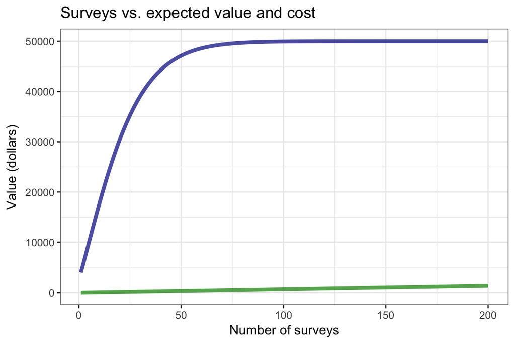

```r
ggplot(value_by_n, aes(x = n, y = pub_value)) +
  theme_bw() +
  geom_line(color = 'blue4', size = 1.5, alpha = .7) +
  geom_line(aes(y = cn), color = 'green4', size = 1.5, alpha = .7) +
  labs(x = 'Number of surveys',
       y = 'Value (dollars)',
       title = 'Surveys vs. expected value and cost')
```

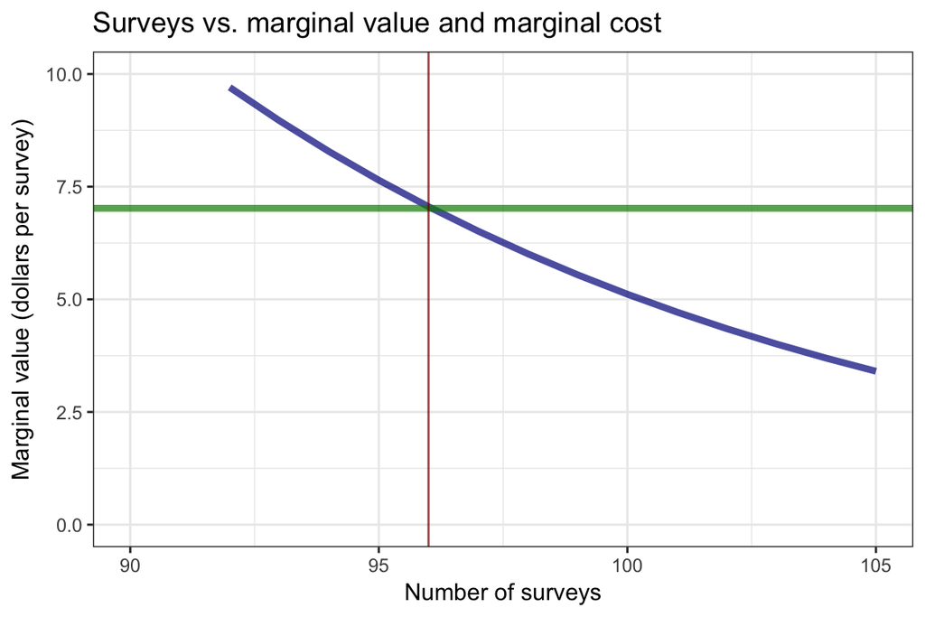

```r
ggplot(value_by_n, aes(x = n, y = dval_dn)) +
  theme_bw() +
  geom_line(color = 'blue4', size = 1.5, alpha = .7) +
  geom_hline(aes(yintercept = naira_to_dollars), color = 'green4', size = 1.5, alpha = .7) +
  geom_vline(xintercept = 96, color = 'red4', alpha = .7) +
  xlim(c(90, 105)) + ylim(c(0, 10)) +
  labs(x = 'Number of surveys',
       y = 'Marginal value (dollars per survey)',
       title = 'Surveys vs. marginal value and marginal cost')
```